# ML_eval

Sarah Abourakty, Aarthee Baskaran, Shipra Trivedi

4/20/2021

# Heart

### Dataset Explanation

This dataset includes statistics on heart attacks and various physiological risk factors. We aimed to develop a model that would predict the probability of a heart attack based on the patient’s age, cholesterol levels, and resting blood pressure. We chose these factors based on their relevance to heart attacks.

**kNN values**

kNN_res value: 11 20  
kNN_sen value: 0.526  
kNN_acc value: 0.508

```
## Confusion Matrix and Statistics
##
##           Actual
## Prediction  0  1
##          0 11 18
##          1 12 20
##
##                Accuracy : 0.5082
##                  95% CI : (0.377, 0.6386)
##     No Information Rate : 0.623
##     P-Value [Acc > NIR] : 0.9749
##
##                   Kappa : 0.0044
##
##  Mcnemar's Test P-Value : 0.3613
##
##             Sensitivity : 0.5263
##             Specificity : 0.4783
##          Pos Pred Value : 0.6250
##          Neg Pred Value : 0.3793
##              Prevalence : 0.6230
##          Detection Rate : 0.3279
##    Detection Prevalence : 0.5246
##       Balanced Accuracy : 0.5023
##
##        'Positive' Class : 1
##
```

### Adjusting threshold

```
## Confusion Matrix and Statistics
##
##           Actual
## Prediction  0  1
##          0  0  0
##          1 23 38
##
##                Accuracy : 0.623
##                  95% CI : (0.4896, 0.7439)
##     No Information Rate : 0.623
##     P-Value [Acc > NIR] : 0.5567
##
##                   Kappa : 0
##
##  Mcnemar's Test P-Value : 4.49e-06
##
##             Sensitivity : 1.0000
##             Specificity : 0.0000
##          Pos Pred Value : 0.6230
##          Neg Pred Value :    NaN
##               Precision : 0.6230
##                  Recall : 1.0000
##                      F1 : 0.7677
##              Prevalence : 0.6230
##          Detection Rate : 0.6230
##    Detection Prevalence : 1.0000
##       Balanced Accuracy : 0.5000
##
##        'Positive' Class : 1
##
```

The error of this model is **0.4918033**, indicating that the kNN model is a poor choice for this dataset.

### ROCR

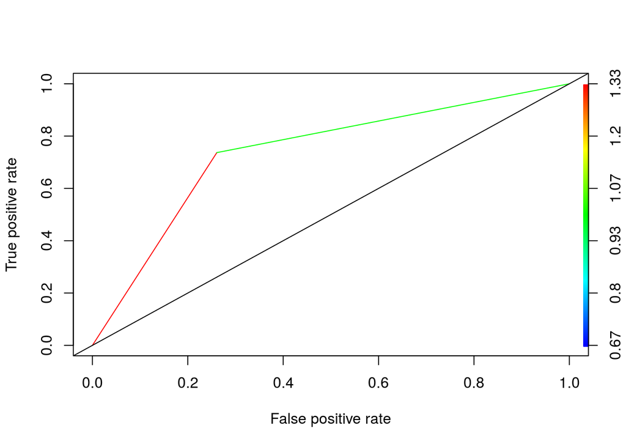

The area under the curve was **0.7379863**, which indicates the model is a fair fit for the model. However, this contradicts with the previously reported kappa and error values.

### LogLoss

A LogLoss value of **3.769976** was observed, which suggests the model is a poor fit for the dataset.

### Analysis

Looking at the various evaluation methods of our model, we can conclude that a kNN model is not the best fit for predicting heart attacks using the age, cholesterol, and resting blood pressure factors. Mis-classification errors were identified in the dataset; the model over-estimated the probability that most individuals would have a heart attack. The model was overly sensitive to the factors.

# Indian Food

### Dataset Explanation

This dataset includes statistics and information on different indian dishes. We aimed to develop a model that would predict the diet (vegetarian or non-vegetarian) of an indian dish based on the prep time, cook time, and region (North, East, South, West, North East, and Central). We chose these factors based on their relevance to indian food diet.

**kNN values**

kNN_res value: 0 39  
kNN_sen value: 1  
kNN_acc value: 0.929

```
## Confusion Matrix and Statistics
##
##           Actual
## Prediction  0  1
##          0  0  0
##          1  3 39
##
##                Accuracy : 0.9286
##                  95% CI : (0.8052, 0.985)
##     No Information Rate : 0.9286
##     P-Value [Acc > NIR] : 0.6473
##
##                   Kappa : 0
##
##  Mcnemar's Test P-Value : 0.2482
##
##             Sensitivity : 1.0000
##             Specificity : 0.0000
##          Pos Pred Value : 0.9286
##          Neg Pred Value :    NaN
##              Prevalence : 0.9286
##          Detection Rate : 0.9286
##    Detection Prevalence : 1.0000
##       Balanced Accuracy : 0.5000
##
##        'Positive' Class : 1
##
```

### Adjusting Threshold

Adjusting the threshold to 0.3 **did not change** the confusion matrix. This is because of the high probability splits and indicates that the model is relying on too few variables and should account for more. This model cannot accurately predict the diet of indian foods even after threshold adjustments.

Additionally, our kappa value was **0** which strongly indicates this model is not the best fit for the dataset. This aligns with the conclusion from the threshold adjustments.

The error for this model was **7%**.

### ROCR

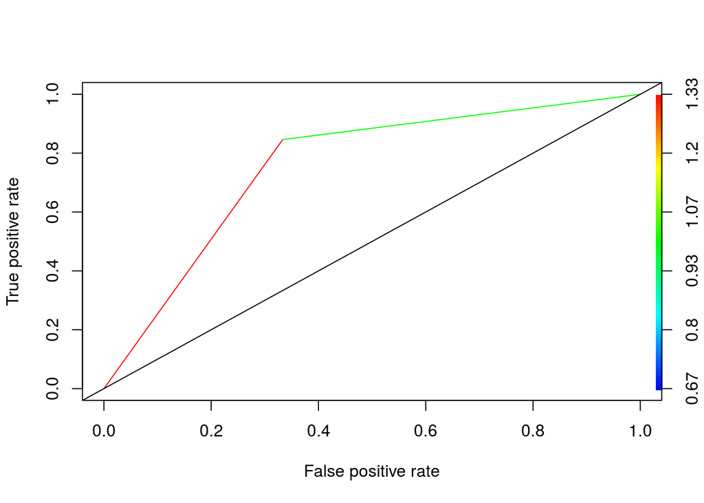

### LogLoss

A LogLoss value of **0.9326** was observed, which suggests the model is a poor fit for the dataset.

An F1_Score of **0.963** was observed. A good F1 score indicates low false positives and low false negatives; our false positives and false negatives are both very low and the model also a high precision and recall. Therefore, this metric indicates our model is a fair fit.

### Analysis

Looking at the various evaluation methods of our model, we can conclude that a kNN model is not the best fit for predicting indian dish diet using the cook time, prep time, and region of the dish. Mis-classification errors were identified in the dataset; the model over-estimated the probability that most dishes would be vegetarian. The model was overly sensitive to the factors. This can be attributed to the nature of this dataset as more quantitative factors could’ve developed a more accurate model.

# Overall conclusion

Overall, the kNN model was not the best choice to evaluate either dataset and make suitable predictions in response to the questions we posed. One recommendation we would consider is adjust the number of neighbors used in the kNN model or use an elbow plot to determine the optimal number of neighbors. Additionally, the threshold can be increased to observe the effects on the confusion matrix and error. Both models are overly sensitive to the factors and may over-estimate the probability of positive cases.